# R Notebook

```r
library(CodeClanData)
library(tidyverse)
library(janitor)
```

```r
# assign all files to an object
revenue_breakdown <- qb_revenue_breakdown
monthly_sales <- qb_monthly_sales
competitors <- qb_competitors
device_data <- qb_device_data

revenue_breakdown <- clean_names(qb_revenue_breakdown)
monthly_sales <- clean_names(qb_monthly_sales)
competitors <- clean_names(qb_competitors)
device_data <- clean_names(qb_device_data)
```

2.1 Part 1

Question 1. Take the data in the dataset qb_revenue_breakdown and make a stacked bar chart showing the sources of revenue across the two years in the dataset.

[figure not shown]

Question 2. Make a line chart showing monthly sales of the “flagship product” - the ‘KwikBit Unit 1’ - over the last year. This data is inside qb_monthly_sales, but you will need to use filter() or subset() (base R). geom_line

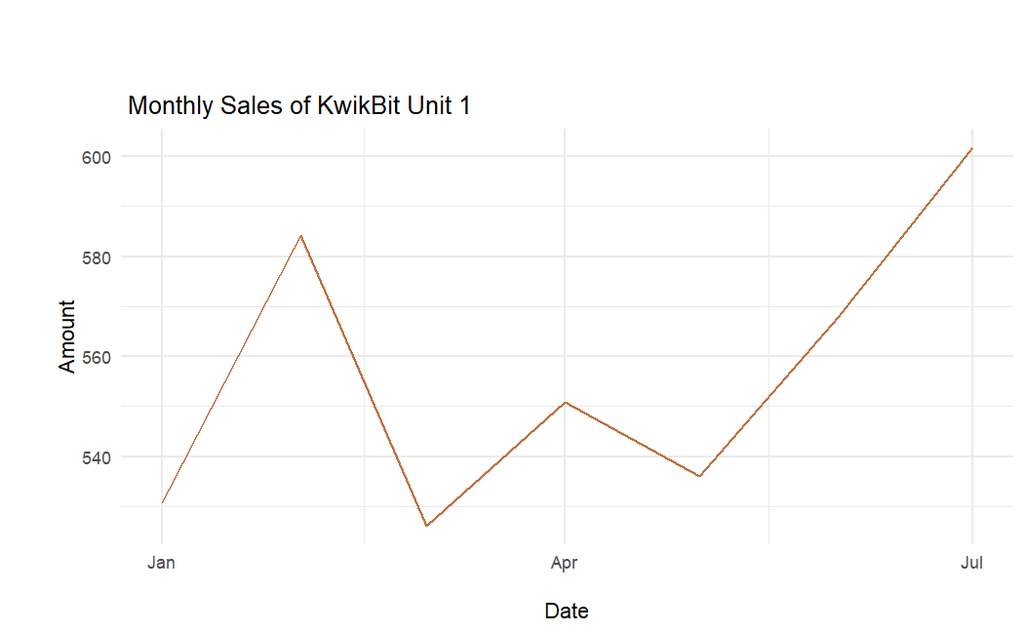

```r
kwik_bit_sales_2019 <- monthly_sales %>%
  filter(cashflow == "Kwikbit Unit 1 Sales", str_sub(date, start = 1, end = 4) == 2019)

ggplot(kwik_bit_sales_2019, aes(x = date, y = amount))+
  geom_line(colour = "#BD7040")+
  labs(
    x = "\nDate",
    y = "\n\nAmount",
    title = "\n\n\n Monthly Sales of KwikBit Unit 1", element_text(size = 28))+
  theme(axis.text = element_text(size = 10))+
  scale_colour_manual(values = col_scheme)+
  theme_minimal()
```

```r
NA
NA
```

Question 3. Make a line chart showing monthly revenue and costs over the last year. This data is also in qb_monthly_sales.

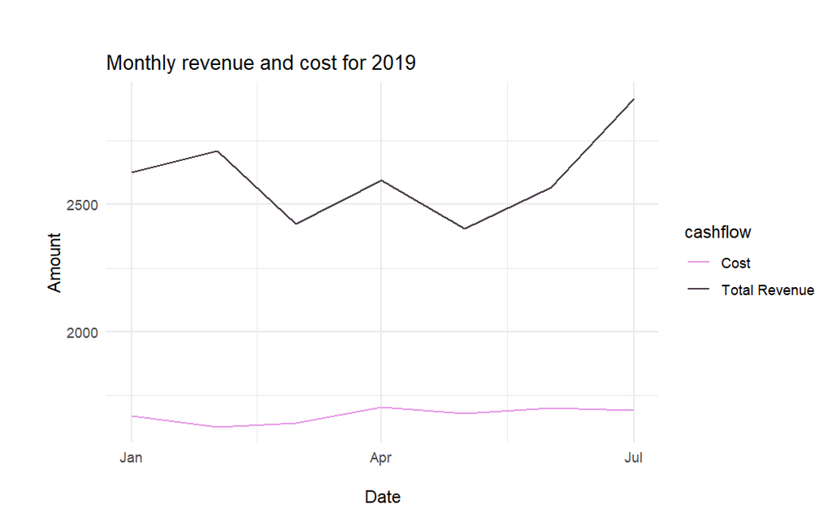

```r
cost_2019 <- monthly_sales %>%
  filter(cashflow == "Cost" | cashflow  == "Total Revenue", str_sub(date, start = 1, end = 4) == 2019)

ggplot(cost_2019, aes(x = date, y = amount, group = cashflow, colour = cashflow))+
  geom_line() +
  labs(x = "\nDate",
  y = "\n\nAmount",
  title = "\n\nMonthly revenue and cost for 2019", element_text(size = 28),
  fill = "Cashflow")+
  theme(axis.text = element_text(size = 10))+
  scale_colour_manual(values = col_scheme)+
  theme_minimal()
```

```r
NA
```

Question 4. Show annual sales of personal fitness trackers over the last 5 years broken down by company as a ribbon plot (use geom_area). This data is in qb_competitors.

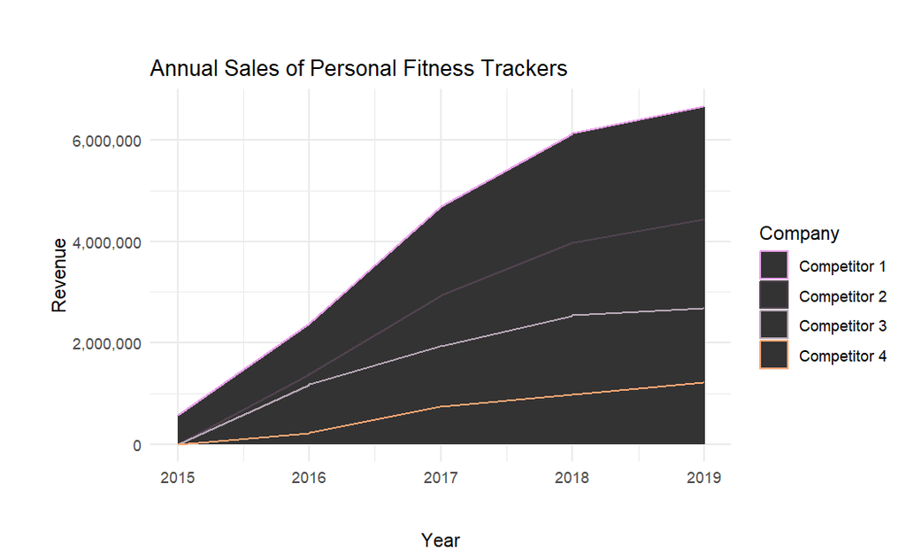

```r
ggplot(competitors)+
  geom_area(aes(x = year , y = revenue, colour = company))+
  scale_y_continuous(labels = scales::comma)+
  labs(
    x = "\n\nYear",
    y = "\n\nRevenue",
    colour = "\n\nCompany",
    title = "\n\nAnnual Sales of Personal Fitness Trackers"
  )+
  theme(axis.text = element_text(size = 10))+
  scale_colour_manual(values = col_scheme)+
  theme_minimal()
```

```r
NA
```

Question 5. Now show the sales from the four competitors as a line graph. Include an extra layer that shows the data points used to make the lines.

[figure not shown]

```r
ggplot(competitors)+
  geom_line(aes(x = year , y = revenue, colour = company))+
  scale_y_continuous(labels = scales::comma)+
  geom_point(aes(x = year , y = revenue, colour = company))+
  labs(
    x = "\n\nRevenue",
    y = "\n\nYear",
    colour = "\n\nCompany",
    title = "\n\nCompetitors revenue in the past 5 years"
  )+
  theme(axis.text = element_text(size = 10))+
  scale_colour_manual(values = col_scheme)+
  theme_minimal()
```

Question 6. Now the company wants to compare the number of steps that their device counts vs. their competitors. Make a line graph of the number of steps throughout time, and use faceting to compare between companies and people. The data for this is in qb_device_data.

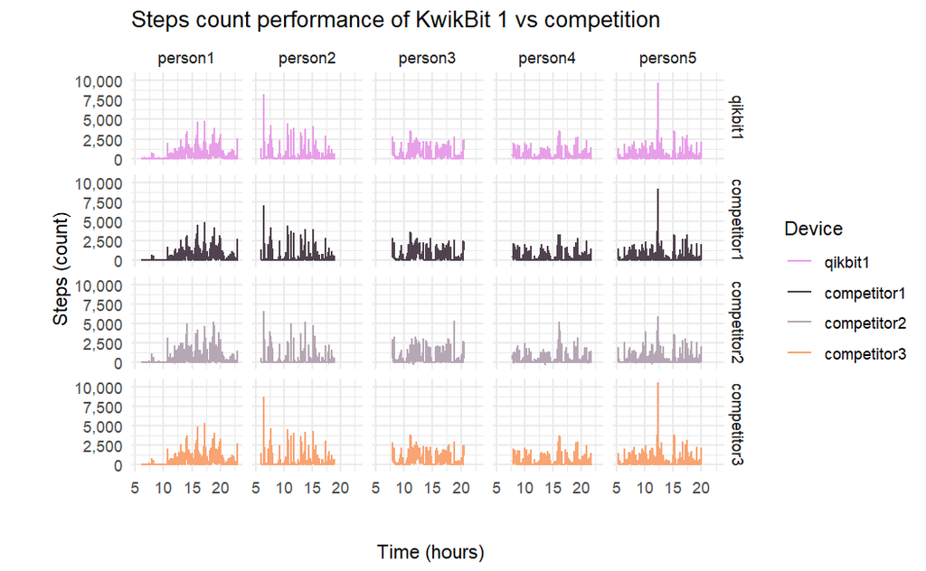